# Flight Delays Prediction / Analytics

Sreekantha Thimmareddy

22 Nov 2017

## Objective

Have you ever been stuck in an airport because your flight was delayed or cancelled and wondered if you could have predicted it if you’d had more data? This is to answer few questions in the context of Airline on-time performance:

. Which Airlines/carrier performs better?

. When is the best time of day/day of week/time of year to fly to minimise delays?

. Do older planes suffer more delays?

. Can you detect cascading failures as delays in one airport create delays in others?

. Create a model to predict flight delays

Note: All the delays are represented in minutes. ##Installing all required packaes

```r
# Packages required
#install.packages("devtools")
#install.packages("rlang") # The package is failing hence using below frm github
#devtools::install_github("tidyverse/rlang", build_vignettes = TRUE)
#install.packages("shiny")
#install.packages("dbplyr")
#install.packages("digest")
#install.packages("backports")
#install.packages("sparklyr") #  If thee package is failing hence using below frm github
#devtools::install_github("rstudio/sparklyr")
#install.packages("sqldf")
#install.packages("corrplot")  # For plotting co-relation
#install.packages("Hmisc") # For co-relation and P values
#install.packages("MASS")  # StepAIC function to choose variables
#install.packages("caret")
#install.packages("R.utils")

library(corrplot)
library(R.utils)
library(sqldf)
library(data.table)
library(caret)
library(stats)
library(devtools)
library(rlang)
library(shiny)
library(dbplyr)
library(digest)
library(backports)
library(sparklyr)
library(ggplot2)  #the cookbook for R: http://www.cookbook-r.com/Graphs/
library(dplyr)
library(DBI)  # For SQL on
#library(MASS)
```

## Loading and Processing Data

```r
# Set Working dir
setwd("D:/Data Science/Flight Data Analysis/")
```

```r
#Download data from Web
#download.file(url="http://stat-computing.org/dataexpo/2009/2007.csv.bz2", destfile = "./Data/2007.csv.bz2")
#download.file(url="http://stat-computing.org/dataexpo/2009/2008.csv.bz2", destfile = "./Data/2008.csv.bz2")
#download.file(url="http://stat-computing.org/dataexpo/2009/airports.csv", destfile = "./Data/airports.csv")
#download.file(url="http://stat-computing.org/dataexpo/2009/carriers.csv", destfile = "./Data/carriers.csv")
#download.file(url="http://stat-computing.org/dataexpo/2009/plane-data.csv", destfile = "./Data/plane_data.csv")

# Unzip files
#bunzip2("./Data/new/2007.csv.bz2", "./Data/2007.csv", remove = FALSE, skip = TRUE)
#bunzip2("./Data/new/2008.csv.bz2", "./Data/2008.csv", remove = FALSE, skip = TRUE)

# Loading data files and working with sample set
# Loading data files and working with sample set
trips2007 <- fread("D:\\Data Science\\Flight Data Analysis\\Data\\2007.csv")  #Fastest way to load large files.

trips2007a <- sample_n(trips2007, 100000)
rm(trips2007)
trips2007a <- as.data.table(trips2007a)

trips2008 <- fread("D:\\Data Science\\Flight Data Analysis\\Data\\2008.csv")
trips2008b <- sample_n(trips2008, 100000)
rm(trips2008)
trips2008b <- as.data.table(trips2008b)

tripsfile <- rbind(trips2007a, trips2008b)

# To free up unused files.
rm(trips2007a, trips2008b)

## Load other supporting files as well. = ",",header = TRUE)
planedatafile <- read.csv2('D:\\Data Science\\Flight Data Analysis\\Data\\plane_data.csv',sep = ",",header = TRUE)
airportsfile <- read.csv2('D:\\Data Science\\Flight Data Analysis\\Data\\airports.csv',sep = ",",header = TRUE)
carriersfile <- read.csv2('D:\\Data Science\\Flight Data Analysis\\Data\\carriers.csv',sep = ",",header = TRUE)

## This is to have copy of raw data untouched available for any reference.


planedata <- planedatafile
airports <- airportsfile
carriers <- carriersfile
trips <- tripsfile
```

## Feature Engineering

```r
summary(trips,message=FALSE, warning=FALSE)
```

```
##       Year          Month          DayofMonth      DayOfWeek
##  Min.   :2007   Min.   : 1.000   Min.   : 1.00   Min.   :1.000
##  1st Qu.:2007   1st Qu.: 4.000   1st Qu.: 8.00   1st Qu.:2.000
##  Median :2008   Median : 6.000   Median :16.00   Median :4.000
##  Mean   :2008   Mean   : 6.461   Mean   :15.73   Mean   :3.928
##  3rd Qu.:2008   3rd Qu.: 9.000   3rd Qu.:23.00   3rd Qu.:6.000
##  Max.   :2008   Max.   :12.000   Max.   :31.00   Max.   :7.000
##
##     DepTime       CRSDepTime      ArrTime       CRSArrTime
##  Min.   :   1   Min.   :   1   Min.   :   1   Min.   :   1
##  1st Qu.: 927   1st Qu.: 925   1st Qu.:1106   1st Qu.:1114
##  Median :1326   Median :1320   Median :1512   Median :1517
##  Mean   :1335   Mean   :1327   Mean   :1481   Mean   :1493
##  3rd Qu.:1730   3rd Qu.:1719   3rd Qu.:1908   3rd Qu.:1905
##  Max.   :2400   Max.   :2359   Max.   :2400   Max.   :2400
##  NA's   :4055                  NA's   :4519
##  UniqueCarrier        FlightNum      TailNum          ActualElapsedTime
##  Length:200000      Min.   :   1   Length:200000      Min.   :  15
##  Class :character   1st Qu.: 602   Class :character   1st Qu.:  76
##  Mode  :character   Median :1537   Mode  :character   Median : 109
##                     Mean   :2200                      Mean   : 127
##                     3rd Qu.:3520                      3rd Qu.: 157
##                     Max.   :9006                      Max.   :1003
##                                                       NA's   :4565
##  CRSElapsedTime     AirTime         ArrDelay           DepDelay
##  Min.   :  1.0   Min.   :  0.0   Min.   :-129.000   Min.   :-168.00
##  1st Qu.: 79.0   1st Qu.: 55.0   1st Qu.:  -9.000   1st Qu.:  -4.00
##  Median :110.0   Median : 85.0   Median :  -1.000   Median :  -1.00
##  Mean   :128.2   Mean   :103.7   Mean   :   9.236   Mean   :  10.77
##  3rd Qu.:158.0   3rd Qu.:131.0   3rd Qu.:  13.000   3rd Qu.:   9.00
##  Max.   :660.0   Max.   :981.0   Max.   :1510.000   Max.   :1518.00
##  NA's   :21      NA's   :4565    NA's   :4565       NA's   :4055
##     Origin              Dest              Distance          TaxiIn
##  Length:200000      Length:200000      Min.   :  24.0   Min.   :  0.000
##  Class :character   Class :character   1st Qu.: 324.0   1st Qu.:  4.000
##  Mode  :character   Mode  :character   Median : 576.0   Median :  6.000
##                                        Mean   : 724.4   Mean   :  6.763
##                                        3rd Qu.: 949.0   3rd Qu.:  8.000
##                                        Max.   :4962.0   Max.   :148.000
##                                                         NA's   :2098
```

[output cut: 9 more lines]

```
##  Min.   :   0.00   Min.   :  0.00   Min.   :   0.00   Min.   :  0.00
##  1st Qu.:   0.00   1st Qu.:  0.00   1st Qu.:   0.00   1st Qu.:  0.00
##  Median :   0.00   Median :  0.00   Median :   0.00   Median :  0.00
##  Mean   :   6.06   Mean   :  1.22   Mean   :   6.18   Mean   :  0.03
##  3rd Qu.:   0.00   3rd Qu.:  0.00   3rd Qu.:   0.00   3rd Qu.:  0.00
##  Max.   :1510.00   Max.   :976.00   Max.   :1093.00   Max.   :297.00
##  NA's   :78177     NA's   :78177    NA's   :78177     NA's   :78177
##  LateAircraftDelay
##  Min.   :  0.00
##  1st Qu.:  0.00
##  Median :  0.00
##  Mean   :  7.87
##  3rd Qu.:  0.00
##  Max.   :797.00
##  NA's   :78177
```

```r
head(filter(trips,  WeatherDelay == 0 ))
```

```
##   Year Month DayofMonth DayOfWeek DepTime CRSDepTime ArrTime CRSArrTime
## 1 2007     7         26         4    1800       1755    2308       2230
## 2 2007     8          1         3     753        755     837        844
## 3 2007     6         23         6    1328       1300    1535       1507
## 4 2007     3         26         1    1558       1559    1857       1914
## 5 2007    12          2         7     806        815     939        949
## 6 2007    12         17         1    1121       1120    1427       1435
##   UniqueCarrier FlightNum TailNum ActualElapsedTime CRSElapsedTime AirTime
## 1            AA       762  N492AA               248            215     187
## 2            OO      5608  N234SW                44             49      27
## 3            AS       526  N647AS               127            127     108
## 4            AA      1523  N5FRAA               179            195     146
## 5            OO      6404  N971SW                93             94      74
## 6            WN      1025  N628SW               126            135     113
##   ArrDelay DepDelay Origin Dest Distance TaxiIn TaxiOut Cancelled
```

[output cut: 20 more lines]

We can see there are ~40% of values are NAs for WeatherDelay, NASDelays, SecurityDelay, LateAircraftDelay. We cannot eaither mark them as zero or backfill with other value. It’s best to omit and use remaining data or exclude these variables in prediction. We can try both. And in other variables, small number of NAs present and we can omit them as well.

Creating hour variables as the time is in HHMM format and not suitable for analysis.

```r
trips$ArrHour <- trunc(trips$CRSArrTime/100)
trips$DepHour <- trunc(trips$CRSDepTime/100)
```

Deviding day into 4 time periods for analysis have devided 24 hours into 4 buckets. i.e new variables DepTimeOfDay, ArrTimeOfDay - 12am to 5:59 am as 0 (Night) - 6am to 11:59 am as 1 (Morning) - 12noon to 5:59pm (Afternoon) - 6pm to 11:59pm (Evening)

```r
trips$ArrTimeofday <- trunc(trips$ArrHour/6)
trips$DepTimeofday <- trunc(trips$DepHour/6)
```

To see week of month has any significance. It may.

```r
trips$WeekOfMonth <- trunc(trips$DayofMonth/7+1)
```

Clearly based on data, the dependent variables are DepDelay and ArrDelay which is the total delay. Adding week of month.

### Joining the supporting data set.

Now let us merge/join supporting data set. This is to make one big de-normalized flat table with all the data fields required available. This can be done after initial EDA as well to find out which fields ussually to be included/excluded. Since I did some exploration in previous versions of code so doing it ahead before EDA here. First Planedata, not all fields are important. Also need to delete any NAs as we don’t have source to backfill.

```r
planedatanew <- planedata[, c("tailnum","type","manufacturer","aircraft_type","engine_type","year") ]
planedatanew <- na.omit(filter(planedatanew, year != "" ))
planedatanew <- na.omit(planedatanew)

#Now Left join two tables
tripsplane <- merge(x=trips, y=planedatanew , by.x="TailNum", by.y="tailnum", all.x = TRUE)[]

# Now let's use airports

nrow(airports)
airportsnew <- na.omit(airports[, c("iata","city", "state", "country")])
nrow(airportsnew)

#Merging for Origin Airports
tripsplaneairports <- merge(x=tripsplane, y=airportsnew , by.x="Origin", by.y="iata", all.x = TRUE)[]
setnames(tripsplaneairports, old = c("city", "state", "country"), new= c("Origincity", "Originstate", "Origincountry"))

# Merging for Destination airports
tripsplaneairports <- merge(x=tripsplaneairports, y=airportsnew , by.x="Dest", by.y="iata", all.x = TRUE)[]

#Renaming the columns to reflect correctly
setnames(tripsplaneairports, old = c("city", "state", "country"), new= c("Destcity", "Deststate", "Destcountry"))

# Again some feature Engineering
tripsplaneairports$planeAge <-  tripsplaneairports$Year  - as.numeric(as.character(tripsplaneairports$year))
str(tripsplaneairports$planeAge)


# Let's create date out of year, month, Day of month

 tripsplaneairports$TravelDate <- as.Date(with(tripsplaneairports, paste(Year, Month, DayofMonth,sep="-")), "%Y-%m-%d")
```

## Exploratory Data Analysis

### Before EDA let’s set aside a set of data for independent evaluation of the model at the end.

```r
set.seed(110)
sub_ind <- sample(nrow(tripsplaneairports), floor(nrow(tripsplaneairports) * 0.2))

trips_ind <- tripsplaneairports[sub_ind,]
tripsplaneairports <- tripsplaneairports[-sub_ind,]
```

Let’s do EDA and find out significance of the variables in predicting Flight Delays For Continous variables, we can use co-relation to see how y is co-related to x1, x2 etc.. which is a good starting point to include in the model. For Categorical variables, let’s find if there are patterns.

Also, let us try and answer some of the questions we defined in the objective.

## Which Airlines/Carrier performs better ?

This is bit generic question. We can make an assumption that the ask is in terms of flight delays

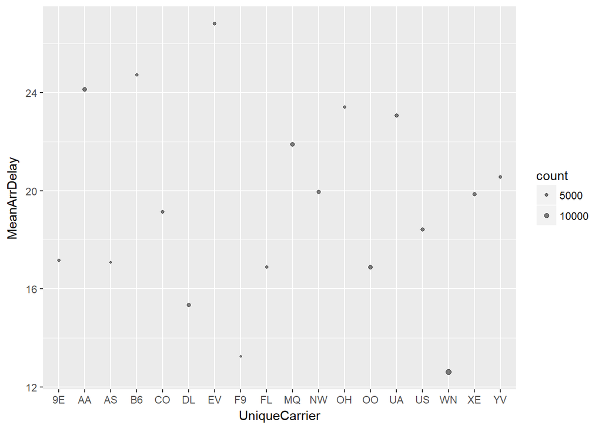

```r
CarrierDelay <- tripsplaneairports %>%
                  group_by(UniqueCarrier) %>%
                  summarise(count=n(), MeanArrDelay = mean(ArrDelay), MeanDepDelay=mean(DepDelay), MeanNASDelay=mean(NASDelay)) %>%
                  filter ( count > 1000, !is.na(MeanArrDelay), !is.na(MeanDepDelay) ) %>%
                  collect

#plot
ggplot(CarrierDelay, aes(UniqueCarrier, MeanArrDelay)) + geom_point(aes(size=count), alpha=1/2) +  scale_size_area(max_size = 2)
```

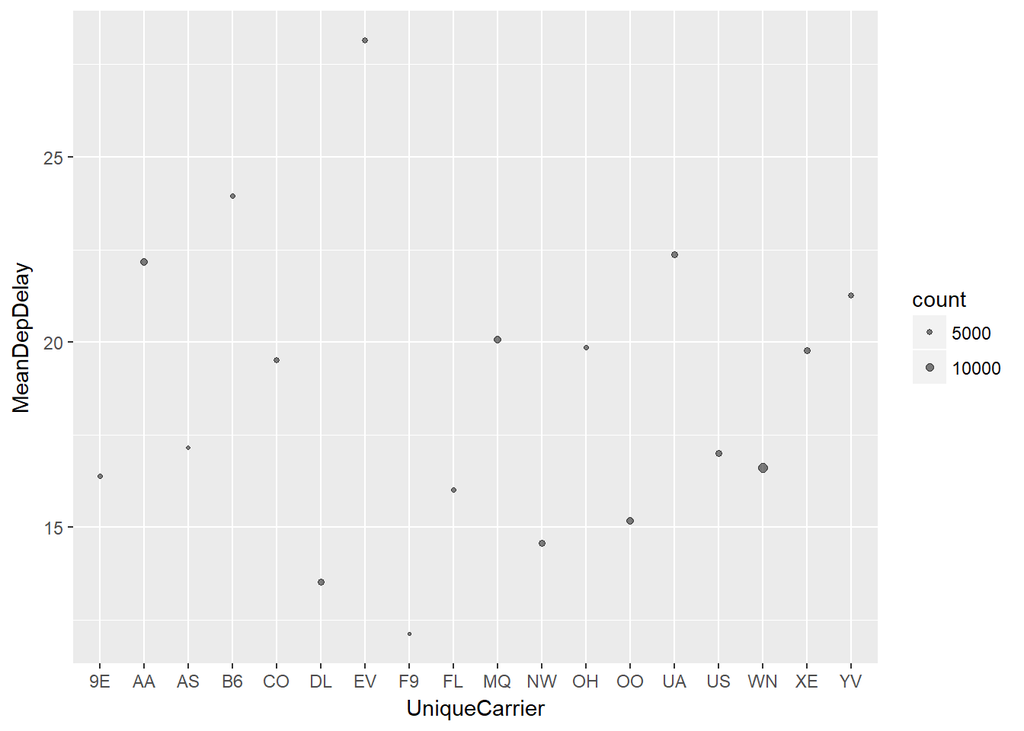

```r
ggplot(CarrierDelay, aes(UniqueCarrier, MeanDepDelay)) + geom_point(aes(size=count), alpha=1/2) +  scale_size_area(max_size = 2)
```

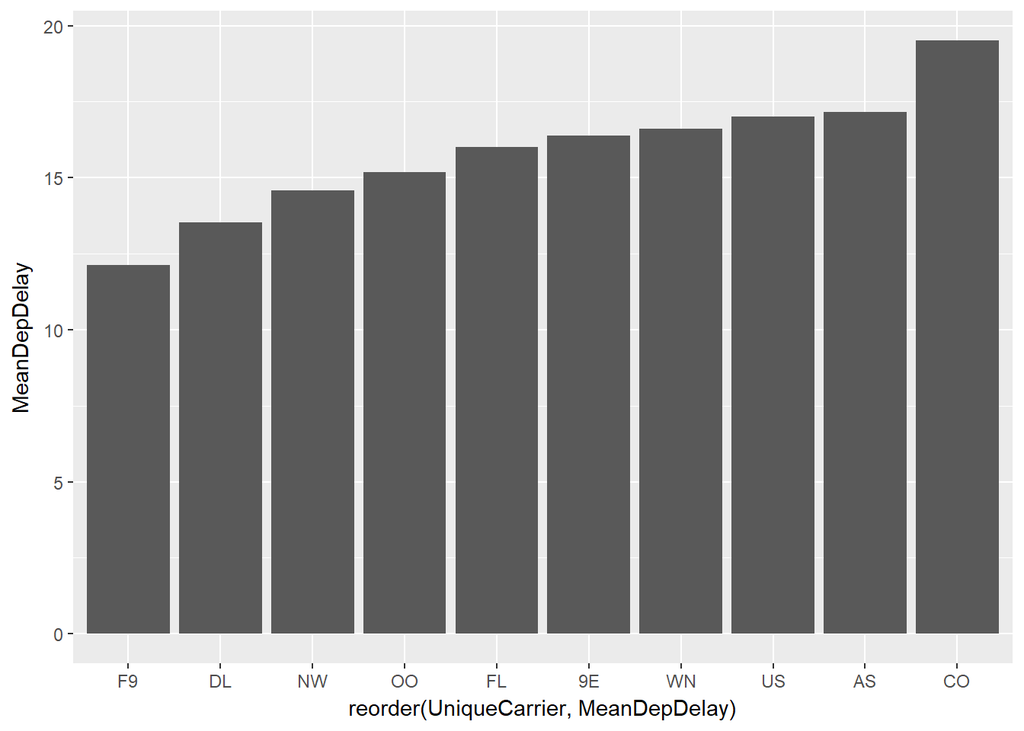

```r
# Same stuff with Bar chart.
CarrierDelay %>% top_n(n=10,- MeanDepDelay ) %>%
ggplot( aes(reorder(UniqueCarrier, MeanDepDelay), MeanDepDelay)) + geom_bar( stat = "identity")
```

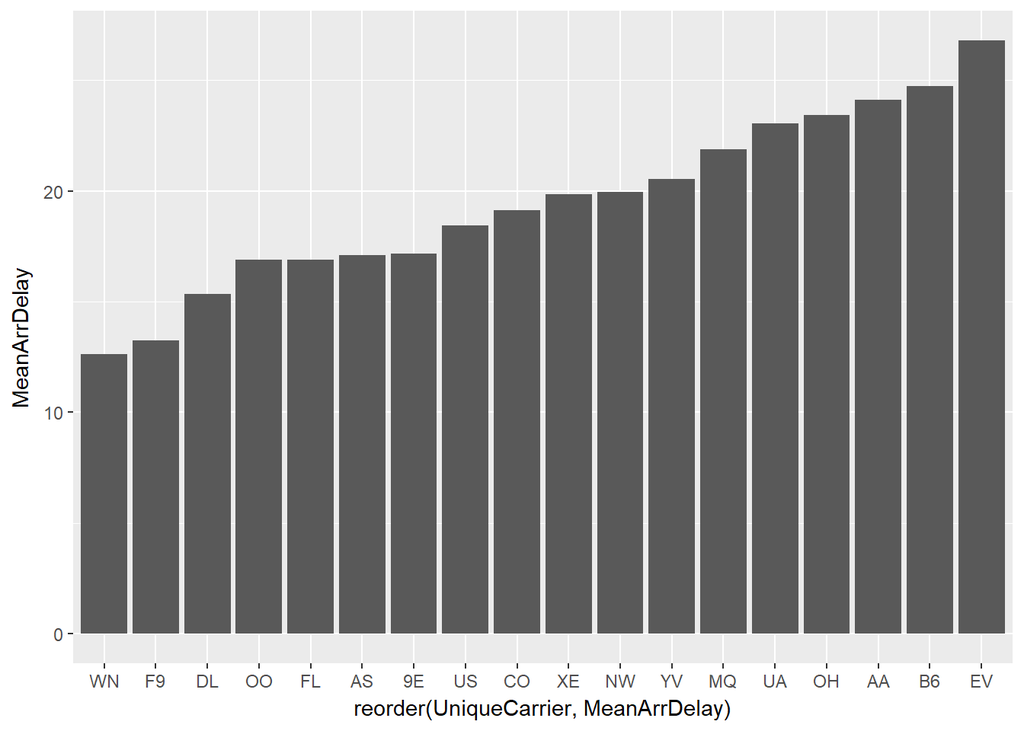

```r
ggplot(CarrierDelay, aes(reorder(UniqueCarrier, MeanArrDelay), MeanArrDelay)) + geom_bar( stat = "identity")
```

Again, Carrier performance differs between Airport to Airport. We can easily apply filter on Airport and get best parforming of Carrier. Or write a simple function to do the same.

#### Origin Airports - Performance

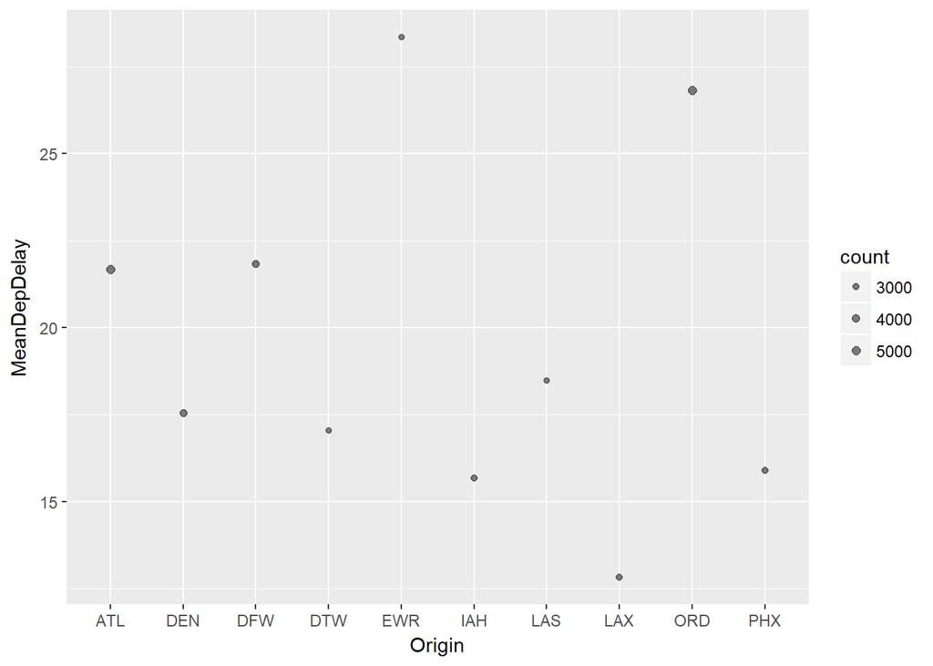

```r
OriginAirportDelay <- tripsplaneairports %>%
  group_by(Origin) %>%
  summarise(count=n(), MeanArrDelay = mean(ArrDelay), MeanDepDelay=mean(DepDelay), MeanWeatherDelay=mean(WeatherDelay)) %>%
  filter ( count > 2000, !is.na(MeanArrDelay), !is.na(MeanDepDelay) ) %>%
  collect
# Increasing count to 2000 for filtering in order to avoid too much cluttering.

#plot
ggplot(OriginAirportDelay, aes(Origin, MeanDepDelay)) + geom_point(aes(size=count), alpha=1/2) + geom_smooth() + scale_size_area(max_size = 2)
```

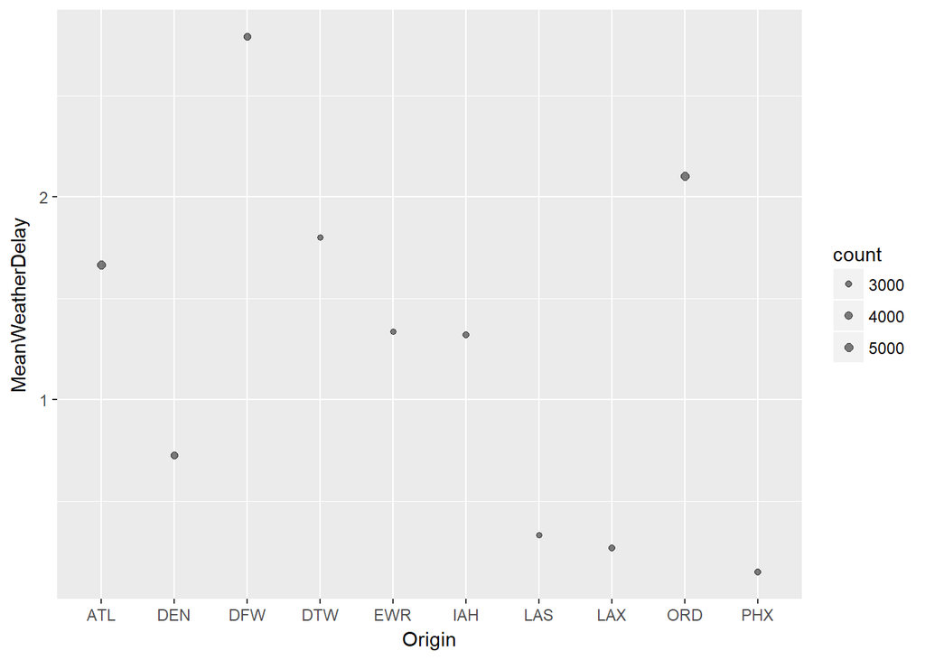

```r
ggplot(OriginAirportDelay, aes(Origin, MeanWeatherDelay)) + geom_point(aes(size=count), alpha=1/2) + geom_smooth() + scale_size_area(max_size = 2)
```

Lax doing better for Departure. Weather is also not much impacted at LAX compared to others. However, except these airports, there is no perticular pattern we can observe. May be we need to combine other variables.

##### Dest Airports - performance

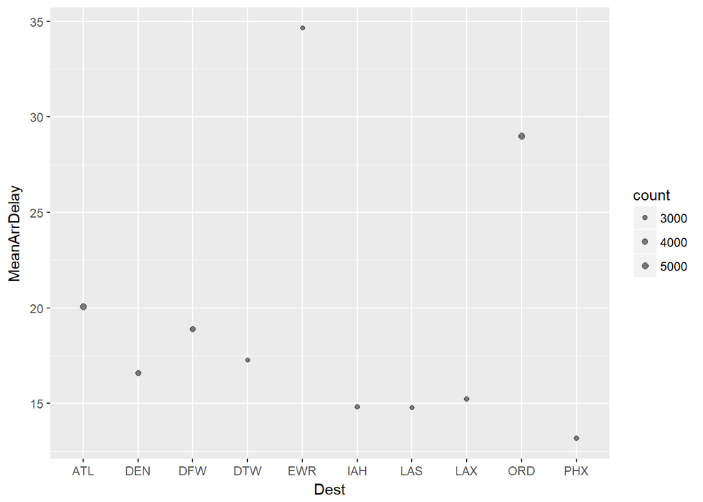

```r
DestAirportDelay <- tripsplaneairports %>%
  group_by(Dest) %>%
  summarise(count=n(), MeanArrDelay = mean(ArrDelay), MeanDepDelay=mean(DepDelay), MeanWeatherDelay2=mean(WeatherDelay)) %>%
  filter ( count > 2000, !is.na(MeanArrDelay), !is.na(MeanDepDelay) ) %>%
  collect
#
#plot
ggplot(DestAirportDelay, aes(Dest, MeanArrDelay)) + geom_point(aes(size=count), alpha=1/2) + geom_smooth() + scale_size_area(max_size = 2)
```

PHX are doing very good with Arrival. And ORD is not so great.

## When is the best time of the day/week/month/year to travel to minimize delays ?

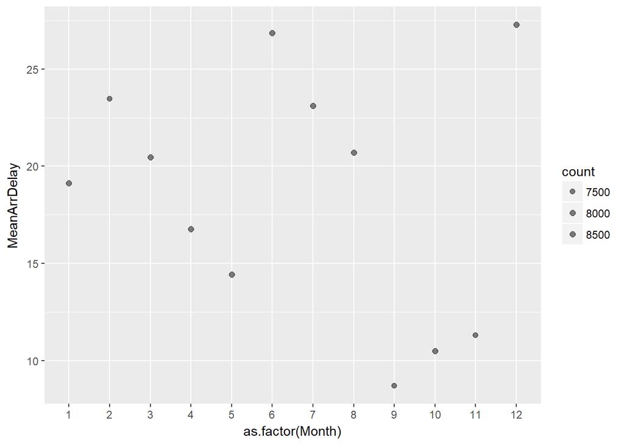

```r
DayMonthDelay <- tripsplaneairports %>%
  group_by(Month) %>%
  summarise(count=n(), MeanArrDelay = mean(ArrDelay), MeanDepDelay=mean(DepDelay), MeanWeatherDelay2=mean(WeatherDelay)) %>%
  filter ( count > 50, !is.na(MeanArrDelay), !is.na(MeanDepDelay) ) %>%
  collect

#plot
ggplot(DayMonthDelay, aes(as.factor(Month), MeanArrDelay)) + geom_point(aes(size=count), alpha=1/2) + geom_smooth() + scale_size_area(max_size = 2)
```

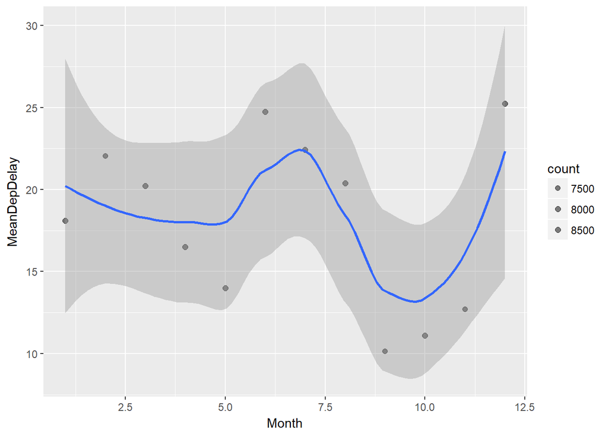

```r
ggplot(DayMonthDelay, aes(Month, MeanDepDelay)) + geom_point(aes(size=count), alpha=1/2) + geom_smooth() + scale_size_area(max_size = 2)
```

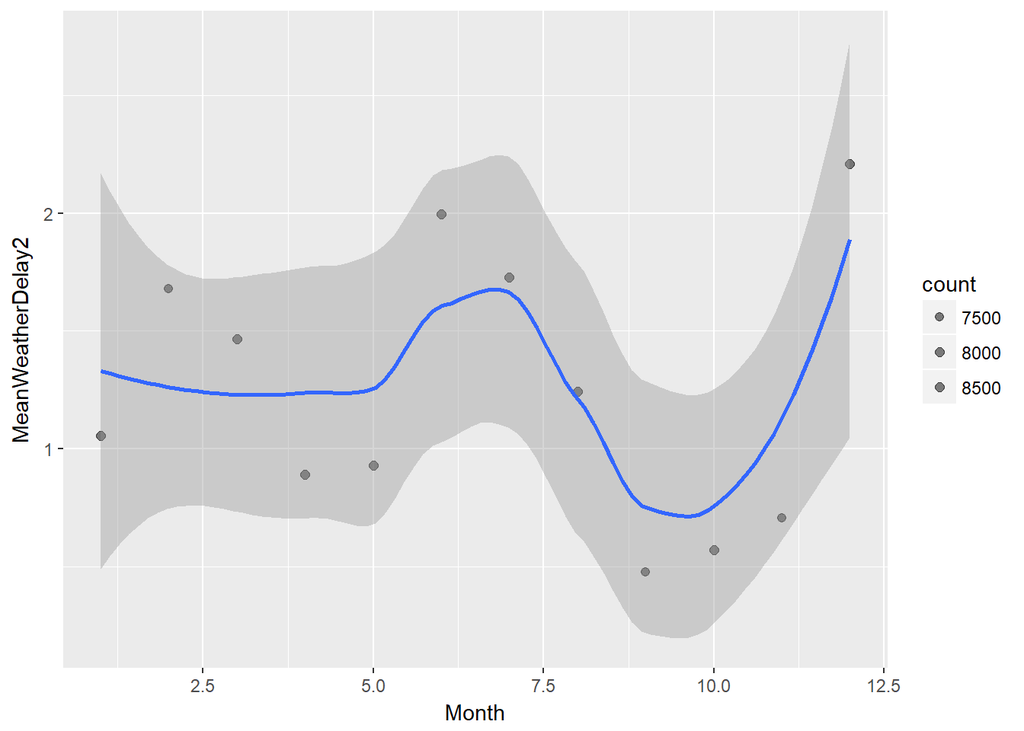

```r
ggplot(DayMonthDelay, aes(Month, MeanWeatherDelay2)) + geom_point(aes(size=count), alpha=1/2) + geom_smooth() + scale_size_area(max_size = 2)
```

We can clearly see Sept, Oct, Nov are the best months to fly as the delays are very min.

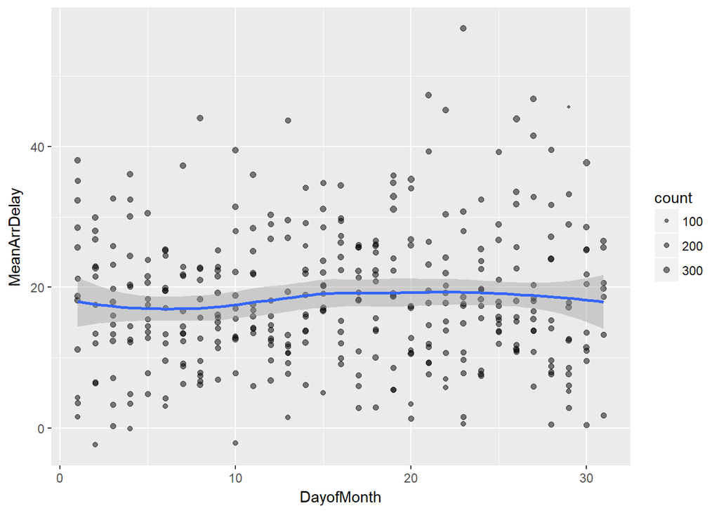

```r
DayofMonthDelay <- tripsplaneairports %>%
  group_by(Month,DayofMonth) %>%
  summarise(count=n(), MeanArrDelay = mean(ArrDelay), MeanDepDelay=mean(DepDelay), MeanWeatherDelay2=mean(WeatherDelay)) %>%
  filter ( count > 50, !is.na(MeanArrDelay), !is.na(MeanDepDelay) ) %>%
  collect

ggplot(DayofMonthDelay, aes(DayofMonth, MeanArrDelay)) + geom_point(aes(size=count), alpha=1/2) + geom_smooth() + scale_size_area(max_size = 2)
```

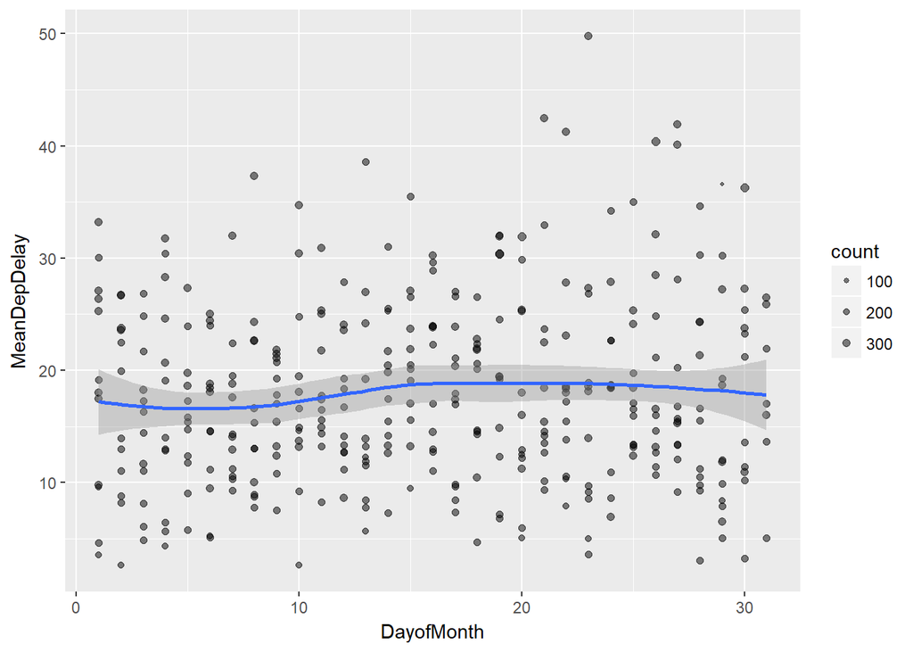

```r
ggplot(DayofMonthDelay, aes(DayofMonth, MeanDepDelay)) + geom_point(aes(size=count), alpha=1/2) + geom_smooth() + scale_size_area(max_size = 2)
```

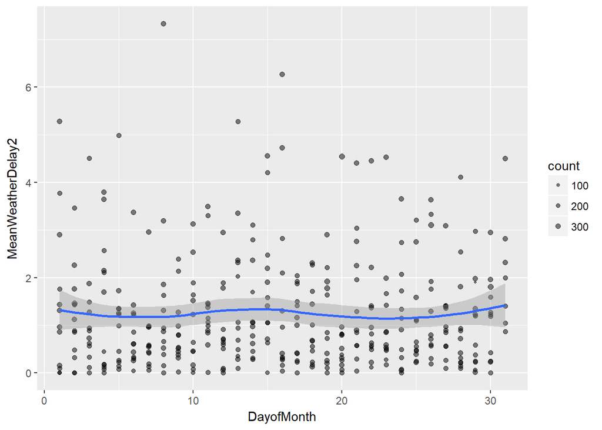

```r
ggplot(DayofMonthDelay, aes(DayofMonth, MeanWeatherDelay2)) + geom_point(aes(size=count), alpha=1/2) + geom_smooth() + scale_size_area(max_size = 2)
```

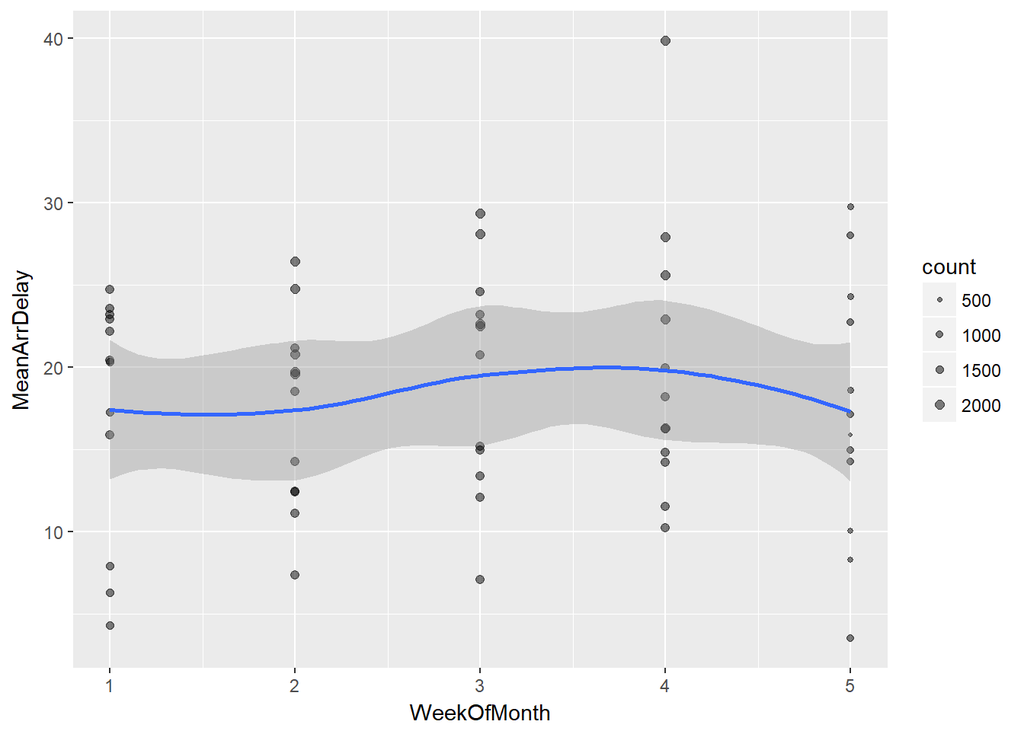

```r
# There is no patteren what so ever. No point in usng this as variable. However, we can try deviding the same by 7 and get the week info to see if there is a patteren.

WeekOfMonthDelay <- tripsplaneairports %>%
  group_by(Month,WeekOfMonth) %>%
  summarise(count=n(), MeanArrDelay = mean(ArrDelay), MeanDepDelay=mean(DepDelay), MeanWeatherDelay2=mean(WeatherDelay)) %>%
  filter ( count > 50, !is.na(MeanArrDelay), !is.na(MeanDepDelay) ) %>%
  collect


ggplot(WeekOfMonthDelay, aes(WeekOfMonth, MeanArrDelay)) + geom_point(aes(size=count), alpha=1/2) + geom_smooth() + scale_size_area(max_size = 2)
```

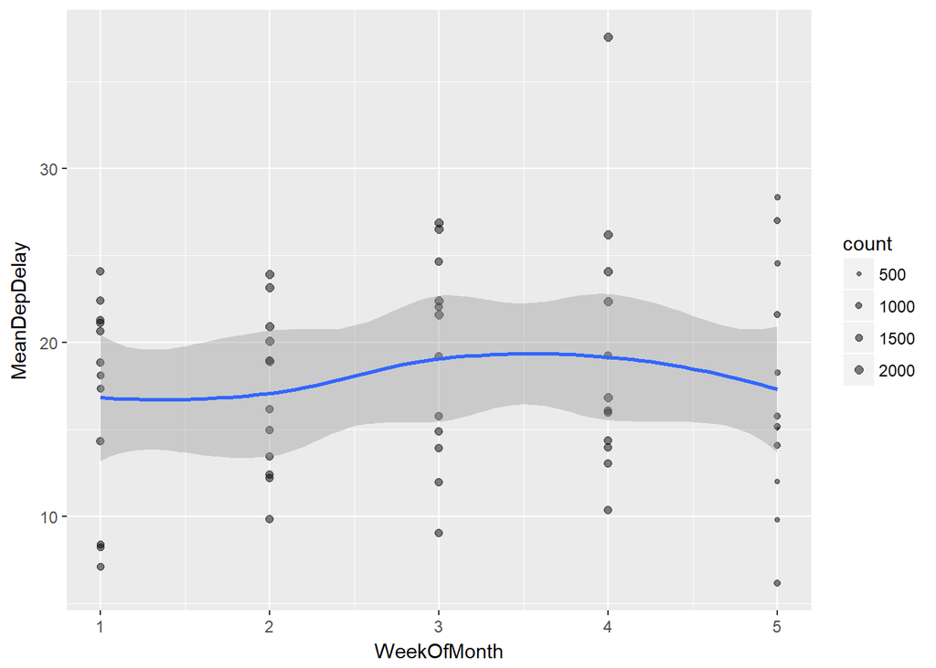

```r
ggplot(WeekOfMonthDelay, aes(WeekOfMonth, MeanDepDelay)) + geom_point(aes(size=count), alpha=1/2) + geom_smooth() + scale_size_area(max_size = 2)
```

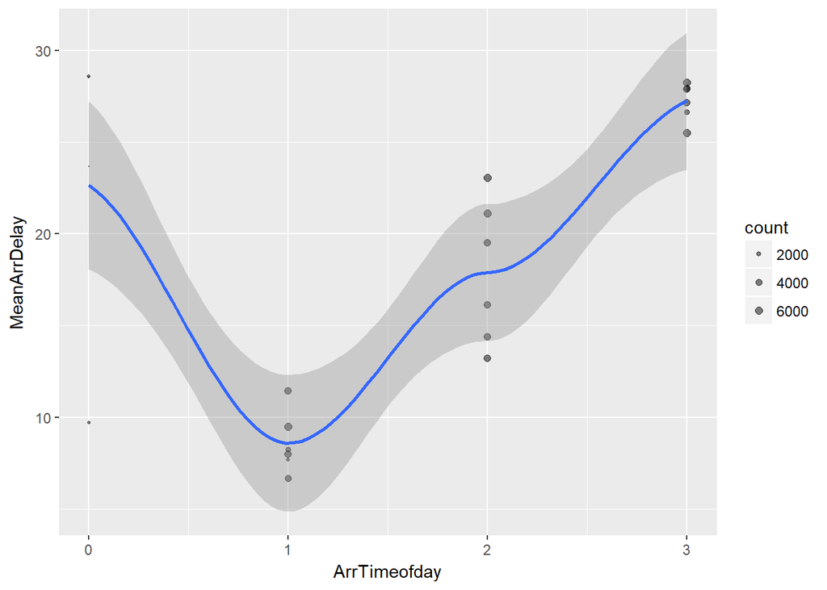

```r
TimeArrDelay <- tripsplaneairports %>%
  group_by(ArrHour,ArrTimeofday) %>%
  summarise(count=n(), MeanArrDelay = mean(ArrDelay), MeanDepDelay=mean(DepDelay), MeanWeatherDelay2=mean(WeatherDelay)) %>%
  filter ( count > 50, !is.na(MeanArrDelay), !is.na(MeanDepDelay) ) %>%
  collect

ggplot(TimeArrDelay, aes(ArrTimeofday, MeanArrDelay)) + geom_point(aes(size=count), alpha=1/2) + geom_smooth() + scale_size_area(max_size = 2)
```

Plan your flight such a way, your sheduled arrival is morning. i.e better overall.

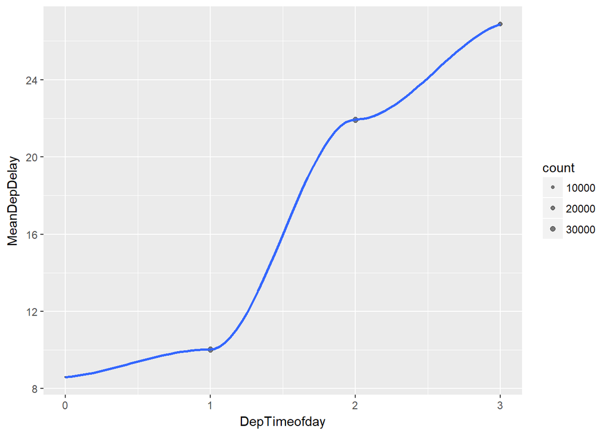

```r
TimeDepDelay <- tripsplaneairports %>%
  group_by(DepTimeofday) %>%
  summarise(count=n(), MeanArrDelay = mean(ArrDelay), MeanDepDelay=mean(DepDelay), MeanWeatherDelay2=mean(WeatherDelay)) %>%
  filter ( count > 50, !is.na(MeanArrDelay), !is.na(MeanDepDelay) ) %>%
  collect

ggplot(TimeDepDelay, aes(DepTimeofday, MeanDepDelay)) + geom_point(aes(size=count), alpha=1/2) + geom_smooth() + scale_size_area(max_size = 2)
```

Generally Departure delays keeps increasing as day prgress. So early morning flights are better.

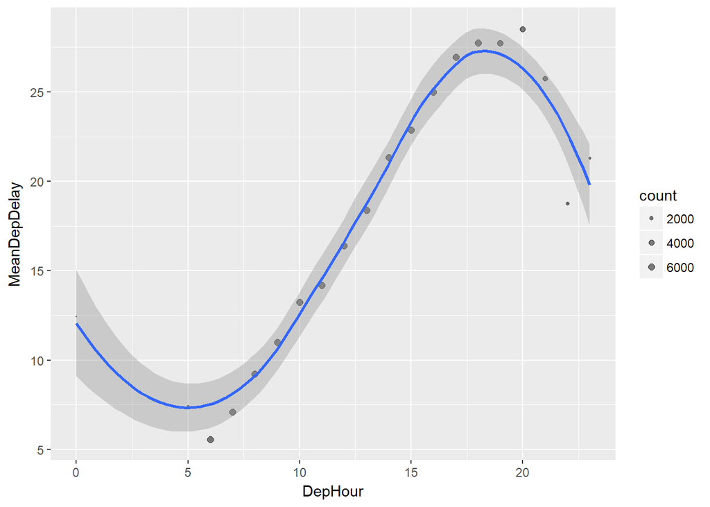

```r
HourDepDelay <- tripsplaneairports %>%
  group_by(DepHour) %>%
  summarise(count=n(), MeanArrDelay = mean(ArrDelay), MeanDepDelay=mean(DepDelay), MeanWeatherDelay2=mean(WeatherDelay)) %>%
  filter ( count > 50, !is.na(MeanArrDelay), !is.na(MeanDepDelay) ) %>%
  collect

ggplot(HourDepDelay, aes(DepHour, MeanDepDelay)) + geom_point(aes(size=count), alpha=1/2) + geom_smooth() + scale_size_area(max_size = 2)
```

Clearly 5-10am departures are better. and almost very negligible delays of less then ~10min.